# Import et nettoyage

Mohamed Maftah (mohamed.maftah@polymtl.ca) & Mehdi Miah (mehdi.miah@gmail.com)

16-04-2018

**Descriptif** : ouvre le fichier d’origine qui contient toutes les données et filtre sur la catégorie ‘Electronics’

# 1 Setup

```r
# Suppression des variables
rm(list = ls())

# Chargement des librairies
library(data.table) #pour fread
library(knitr) #pour le notebook
library(stringr)
library(ggplot2)
library(tidyr)
library(dplyr)
```

# 2 Ouverture du fichier

```r
# Eléments considérés comme NA
na_strings = c(NA, '', '.', ' ', '?')

# Dataset au complet
full_dataset = fread("./data/input/train.tsv",
                     stringsAsFactors = FALSE, data.table = FALSE,
                     sep = "\t", encoding = "UTF-8", na.strings = na_strings)
```

```
##
Read 0.0% of 1482535 rows
Read 14.8% of 1482535 rows
Read 25.6% of 1482535 rows
Read 37.8% of 1482535 rows
Read 54.0% of 1482535 rows
Read 74.2% of 1482535 rows
Read 84.3% of 1482535 rows
Read 91.1% of 1482535 rows
Read 1482535 rows and 8 (of 8) columns from 0.315 GB file in 00:00:14
```

```r
head(full_dataset)
```

| train_id | name | item_condition_id | category_name | brand_name | price | shipping | item_description |
| --- | --- | --- | --- | --- | --- | --- | --- |
| 0 | MLB Cincinnati Reds T Shirt Size XL | 3 | Men/Tops/T-shirts | NA | 10 | 1 | No description yet |
| 1 | Razer BlackWidow Chroma Keyboard | 3 | Electronics/Computers & Tablets/Components & Parts | Razer | 52 | 0 | This keyboard is in great condition and works like it came out of the box. All of the ports are tested and work perfectly. The lights are customizable via the Razer Synapse app on your PC. |
| 2 | AVA-VIV Blouse | 1 | Women/Tops & Blouses/Blouse | Target | 10 | 1 | Adorable top with a hint of lace and a key hole in the back! The pale pink is a 1X, and I also have a 3X available in white! |
| 3 | Leather Horse Statues | 1 | Home/Home Décor/Home Décor Accents | NA | 35 | 1 | New with tags. Leather horses. Retail for [rm] each. Stand about a foot high. They are being sold as a pair. Any questions please ask. Free shipping. Just got out of storage |
| 4 | 24K GOLD plated rose | 1 | Women/Jewelry/Necklaces | NA | 44 | 0 | Complete with certificate of authenticity |
| 5 | Bundled items requested for Ruie | 3 | Women/Other/Other | NA | 59 | 0 | Banana republic bottoms, Candies skirt with matching blazer,Amy Byers suit, Loft bottoms and cami top. |

```r
str(full_dataset)
```

```
## 'data.frame':    1482535 obs. of  8 variables:
##  $ train_id         : int  0 1 2 3 4 5 6 7 8 9 ...
##  $ name             : chr  "MLB Cincinnati Reds T Shirt Size XL" "Razer BlackWidow Chroma Keyboard" "AVA-VIV Blouse" "Leather Horse Statues" ...
##  $ item_condition_id: int  3 3 1 1 1 3 3 3 3 3 ...
##  $ category_name    : chr  "Men/Tops/T-shirts" "Electronics/Computers & Tablets/Components & Parts" "Women/Tops & Blouses/Blouse" "Home/Home Décor/Home Décor Accents" ...
##  $ brand_name       : chr  NA "Razer" "Target" NA ...
##  $ price            : num  10 52 10 35 44 59 64 6 19 8 ...
##  $ shipping         : int  1 0 1 1 0 0 0 1 0 0 ...
##  $ item_description : chr  "No description yet" "This keyboard is in great condition and works like it came out of the box. All of the ports are tested and work"| __truncated__ "Adorable top with a hint of lace and a key hole in the back! The pale pink is a 1X, and I also have a 3X available in w…
```

Expliquons les données : chaque instance correspond à un produit, identifié par la variable **train_id**. Ce produit est nommé dans **name**, son état (neuf, d’occasion ou très abimé) est indiqué par **item_condition_id**. De plus, ce produit appartient à des catégories (hiérarchie crée par Mercari) présentés dans **category_name**. Lorsqu’une marque est identifiable, elle est mentionnée dans **brand_name**. Enfin, le prix de vente est indiqué dans **price** ainsi que les frais de port dans **shipping**. En dernier lieu, une description textuelle complète l’article par **item_description**.

Il est à noté que Kaggle a supprimé toute mention d’un prix dans les noms et descriptions des articles : ces mentions ont été remplacées par des “[rm]”.

# 3 Filtre sur la catégorie *Electronics*

On ne conserve que les produits dans la catégorie *Electronics*. L’information est comprise dans la variable **category_name** dont il faut séparer les sous-catégories.

Première question : combien de niveau de catégorie existe-il ? A première vue, on dirait 3.

```r
full_dataset$category_name %>% str_count("/") %>% as.factor() %>% summary()
```

```
##       2       3       4    NA's
## 1471819    1330    3059    6327
```

Il s’avère qu’il y a des produits qui n’ont aucune catégorie, soit 3, 4, ou 5 (en effet, le nombre indiqué dans le code est le nombre de séparateur).

Créons donc 5 colonnes : de **cat1** à **cat5**. Lorsque la donnée est manquante, elle prendra la valeur NA.

```r
full_dataset = full_dataset %>%
  separate(category_name, c("cat1", "cat2", "cat3", "cat4", "cat5"), sep = "/", remove = TRUE)
```

Visualisons le résultat :

```r
head(full_dataset)
```

| train_id | name | item_condition_id | cat1 | cat2 | cat3 | cat4 | cat5 | brand_name | price | shipping | item_description |
| --- | --- | --- | --- | --- | --- | --- | --- | --- | --- | --- | --- |
| 0 | MLB Cincinnati Reds T Shirt Size XL | 3 | Men | Tops | T-shirts | NA | NA | NA | 10 | 1 | No description yet |
| 1 | Razer BlackWidow Chroma Keyboard | 3 | Electronics | Computers & Tablets | Components & Parts | NA | NA | Razer | 52 | 0 | This keyboard is in great condition and works like it came out of the box. All of the ports are tested and work perfectly. The lights are customizable via the Razer Synapse app on your PC. |
| 2 | AVA-VIV Blouse | 1 | Women | Tops & Blouses | Blouse | NA | NA | Target | 10 | 1 | Adorable top with a hint of lace and a key hole in the back! The pale pink is a 1X, and I also have a 3X available in white! |
| 3 | Leather Horse Statues | 1 | Home | Home Décor | Home Décor Accents | NA | NA | NA | 35 | 1 | New with tags. Leather horses. Retail for [rm] each. Stand about a foot high. They are being sold as a pair. Any questions please ask. Free shipping. Just got out of storage |
| 4 | 24K GOLD plated rose | 1 | Women | Jewelry | Necklaces | NA | NA | NA | 44 | 0 | Complete with certificate of authenticity |
| 5 | Bundled items requested for Ruie | 3 | Women | Other | Other | NA | NA | NA | 59 | 0 | Banana republic bottoms, Candies skirt with matching blazer,Amy Byers suit, Loft bottoms and cami top. |

Désormais, nous sommes en mesure de sélectionner les produits en lien avec l’électronique. Mais avant cela, calculons quelques statistiques sur l’ensemble des données.

Deuxième question : quels sont les autres catégories et quels sont leur volume ?

```r
# Proportions d'articles par cat1
table(full_dataset$cat1) %>% prop.table() %>% sort(decreasing = TRUE)
```

```
##
##                  Women                 Beauty                   Kids
##             0.45006192             0.14078504             0.11630407
##            Electronics                    Men                   Home
##             0.08311159             0.06345989             0.04597658
## Vintage & Collectibles                  Other               Handmade
##             0.03151995             0.03072128             0.02089272
##      Sports & Outdoors
##             0.01716696
```

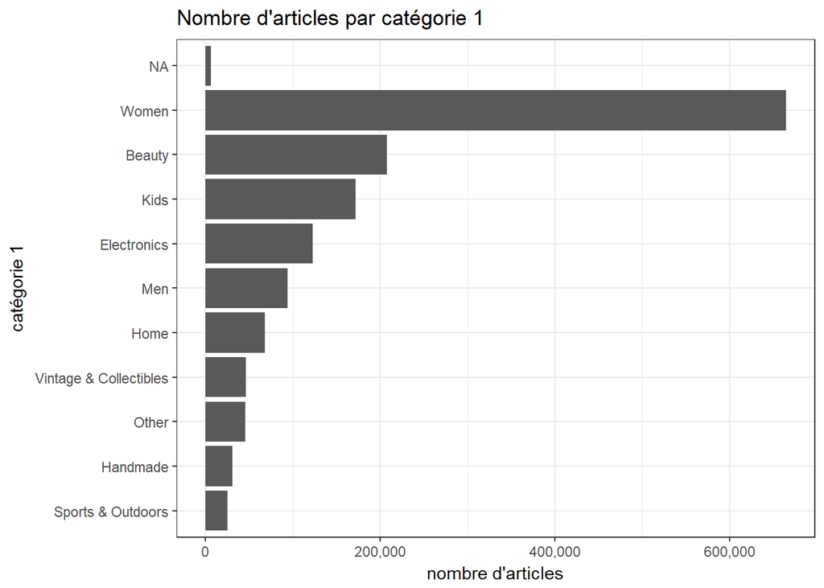

```r
# Dataframe avec le nombre d'articles par catégorie 1
n_articles_cat1 = full_dataset %>%
  group_by(cat1) %>%
  summarise(effectif = n()) %>%
  ungroup()

# Ordonne les catégories pour avoir du plus grand au plus petit
n_articles_cat1$cat1 = factor(n_articles_cat1$cat1,
                              levels = n_articles_cat1$cat1[order(n_articles_cat1$effectif)])

# Graphique en barre
ggplot(n_articles_cat1, aes(x = cat1, y = effectif)) +
  geom_bar(stat = 'identity') +
  labs(title = "Nombre d'articles par catégorie 1",
       x = "catégorie 1",
       y = "nombre d'articles") +
  scale_y_continuous(labels = scales::comma) +
  coord_flip() +
  theme_bw()
```

```r
# Nombre d'articles au total
cat(sprintf("Nombre total d'articles : %.0f", nrow(full_dataset)))
```

```
## Nombre total d'articles : 1482535
```

```r
# Nombre d'articles en électroniques
cat(sprintf("Nombre d'articles en électronique : %.0f",
        sum(full_dataset$cat1 == "Electronics", na.rm = TRUE)))
```

```
## Nombre d'articles en électronique : 122690
```

Ainsi les produits électroniques représentent 8.3% des articles de la base de données, soit près de 123 000 éléments.

Mesurons l’écart-type des prix au sein de chaque catégorie 1.

```r
sd_price_cat1 = full_dataset %>%
  group_by(cat1) %>%
  summarise(min_price = min(price),
            max_price = max(price),
            sd_price = sd(price)) %>%
  ungroup() %>%
  arrange(-sd_price)
sd_price_cat1
```

| cat1 | min_price | max_price | sd_price |
| --- | --- | --- | --- |
| Electronics | 0 | 1909 | 65.41978 |
| Vintage & Collectibles | 0 | 1709 | 53.50749 |
| Men | 0 | 1309 | 41.24006 |
| Women | 0 | 2009 | 39.44385 |
| NA | 0 | 1000 | 34.11442 |
| Other | 0 | 1400 | 29.84776 |
| Sports & Outdoors | 0 | 915 | 29.30223 |
| Handmade | 0 | 1750 | 27.75829 |
| Home | 0 | 848 | 24.41706 |
| Kids | 0 | 809 | 22.73088 |
| Beauty | 0 | 2000 | 21.36014 |

La catégorie *Electronics* est celui où la variance des prix est la plus forte. Ainsi, il semblerait qu’elle soit donc la catégorie offrant le plus de difficulté, au sens de la pénalité et du risque encouru.

# 4 Etude sur les produits électroniques

## 4.1 Obtention des données

```r
dataset = full_dataset %>%
  filter(cat1 == "Electronics")  %>%
  select(-cat1, -cat4, -cat5) #cat1 est unique dans ce cas ; cat4 et cat5 sont très souvent manquant
```

## 4.2 Traitement préliminaire des données

Cette partie est importante dans le traitement du problème. En effet, à partir des résultats obtenus ci-dessous, il sera possible de préciser le périmètre de travail, de gérer les valeurs manquantes, de regrouper certaines modalités rares et de vérifier la cohérence des données.

### 4.2.1 Données manquantes

Vérifions la part de données manquantes :

```r
# Comptage de données manquantes par variable
colSums(is.na(dataset)) %>% sort()
```

```
##          train_id item_condition_id              cat2              cat3
##                 0                 0                 0                 0
##             price          shipping              name  item_description
##                 0                 0                 1                10
##        brand_name
##             62629
```

Traitons les variables impactées :

- 1 observation n’a pas de nom : nous la laissons telle quelle ;
- 10 observations ne contiennent pas de description : nous les traitons en les remplaçants par l’indicateur “No description yet” ;
- 62629 observations n’ont pas de marque : a priori, les produits tels que les accessoires n’ont pas de marque. Ainsi, l’absence de donnée concernant la marque est en soit une information qu’il convient de conserver. Pour cela, nous remplaçons les valeurs manquantes par “brandMissing”.

Regardons de plus près la dizaine d’observations avec soit un nom soit une description manquante :

```r
obs_with_missing_brand_or_description = dataset %>%
  filter(is.na(name) | is.na(item_description))

obs_with_missing_brand_or_description
```

| train_id | name | item_condition_id | cat2 | cat3 | brand_name | price | shipping | item_description |
| --- | --- | --- | --- | --- | --- | --- | --- | --- |
| 393905 | Games | 3 | Video Games & Consoles | Games | NA | 44 | 0 | NA |
| 435489 | Ps1 games | 3 | Video Games & Consoles | Games | NA | 49 | 0 | NA |
| 899494 | All set for [rm] | 1 | Cell Phones & Accessories | Cell Phone Accessories | NA | 12 | 1 | NA |
| 1032054 | Strong flexible tripod mobile and gopro | 1 | Cameras & Photography | Tripods & Supports | NA | 9 | 1 | NA |
| 1143911 | BUNDLE FOR LYNN DALTON | 3 | Media | CD | NA | 16 | 0 | NA |
| 1149332 | Conkers Bad Fur Day box and manual | 4 | Video Games & Consoles | Games | NA | 25 | 1 | NA |
| 1306229 | PS3 games ar nosurge cross edge disgaea | 3 | Video Games & Consoles | Games | NA | 32 | 0 | NA |
| 1333765 | Just Dance 3 | 3 | Video Games & Consoles | Games | NA | 4 | 1 | NA |
| 1368014 | NA | 3 | Computers & Tablets | Components & Parts | Acer | 30 | 1 | NA |
| 1388572 | For Diego9 | 3 | Video Games & Consoles | Games | NA | 34 | 0 | NA |

```r
# Lorsque la marque est manquante, on met une valeur par défaut
dataset$brand_name[is.na(dataset$brand_name)] = "brandMissing"
## Il ne faut pas de '_' au risque de perdre le sens lors de la tokenisation

# Création d'une variable binaire qui permet de considérer l'effet de ne pas mettre de marque, ou bien d'un produit sans marque
dataset$is_brand_missing = dataset$brand_name == "brandMissing" #boolean
```

Normalement, lorsque la description est manquante, Kaggle mettait “No description yet”.

```r
# Nombre de produits explicitement sans description
n_description_missing = sum(dataset$item_description == "No description yet", na.rm = TRUE)

cat(sprintf("Il y a %.0f articles sans description et référencés tel quels.\n",
            n_description_missing))
```

```
## Il y a 7497 articles sans description et référencés tel quels.
```

```r
# Remplacement des NA dans les descriptions par un marqueur
dataset$item_description[is.na(dataset$item_description)] = "NoDescriptionYet"

# On remplace la valeur par défaut qui contient des underscores
dataset$item_description[dataset$item_description == "No description yet"] = "NoDescriptionYet"


# Vérification
n_description_missing = sum(dataset$item_description == "NoDescriptionYet")

cat(sprintf("Désormais, il y a %.0f articles sans description et référencés tel quels.\n",
            n_description_missing))
```

```
## Désormais, il y a 7507 articles sans description et référencés tel quels.
```

Après lecture des spécifications de Kaggle, lorsque le prix était indiqué dans le nom ou dans la description, il était systématiquement remplacé par “[rm]”. Supprimons ces mentions.

```r
# Nombre de fois où "[rm]" apparait
## NB : dans "\\[rm\\]", le premier '\' transforme le second '\' en caractère qui est reconnu dans un caractère spécial
## En savoir plus : https://stackoverflow.com/questions/10294284/remove-all-special-characters-from-a-string-in-r
n_rm_name = grepl(pattern = "\\[rm\\]", dataset$name) %>% sum()
n_rm_description = grepl(pattern = "\\[rm\\]", dataset$item_description) %>% sum()

cat(sprintf("Il y a %.0f mentions de [rm] dans les noms des produits et %.0f dans les descriptions.\n",
            n_rm_name, n_rm_description))
```

```
## Il y a 790 mentions de [rm] dans les noms des produits et 10650 dans les descriptions.
```

```r
# Remplacement
dataset$name = gsub(pattern = "\\[rm\\]", replacement = "", dataset$name)
dataset$item_description = gsub(pattern = "\\[rm\\]", replacement = "", dataset$item_description)
```

Vérifions que la suppression s’est faite correctement :

```r
# Nombre de fois où "[rm]" apparait après correction
n_rm_name = grepl(pattern = "\\[rm\\]", dataset$name) %>% sum()
n_rm_description = grepl(pattern = "\\[rm\\]", dataset$item_description) %>% sum()

cat(sprintf("Il y a %.0f mention de [rm] dans les noms des produits et %.0f dans les descriptions.\n",
            n_rm_name, n_rm_description))
```

```
## Il y a 0 mention de [rm] dans les noms des produits et 0 dans les descriptions.
```

### 4.2.2 Quelques statistiques descriptives

Quelle est la répartition des conditions des produits ?

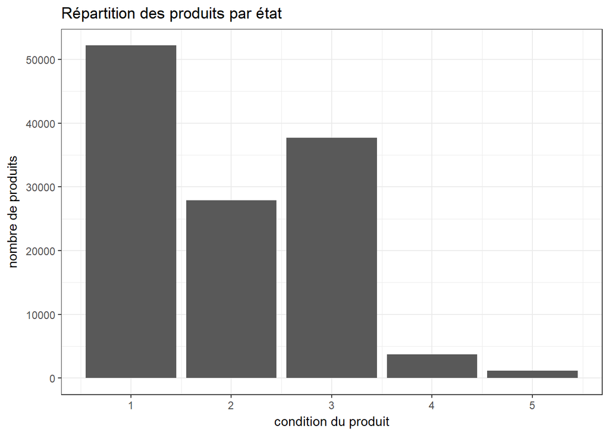

```r
# Dataframe comptant l'état des produits
n_articles_condition = dataset %>%
  group_by(item_condition_id) %>%
  summarise(effectif = n()) %>%
  ungroup()

# Graphique
ggplot(n_articles_condition, aes(x = item_condition_id, y = effectif)) +
  geom_bar(stat = 'identity') +
  labs(title = "Répartition des produits par état",
       x = "condition du produit",
       y = "nombre de produits") +
  theme_bw()
```

La très grande majorité des produits sont soit neufs (condition à 1), soit peu usés (condition à 2 et 3).

Quelle est la répartition par cat2 ?

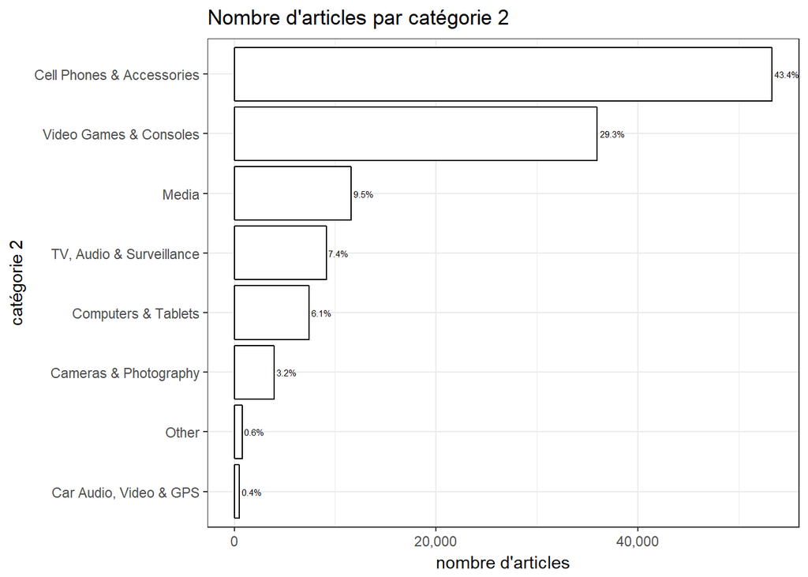

```r
# Dataframe comptant le nombre de produits par cat2
n_articles_cat2 = dataset %>%
  group_by(cat2) %>%
  summarise(effectif = n()) %>% #nombre de produits
  ungroup() %>%
  mutate(pct = 100 * effectif / sum(effectif)) #pourcentage

# Ordonne les levels
n_articles_cat2$cat2 = factor(n_articles_cat2$cat2,
                              levels = n_articles_cat2$cat2[order(n_articles_cat2$effectif)])

# Graphique en barre
ggplot(n_articles_cat2, aes(x = cat2, y = effectif)) +
  geom_bar(stat = 'identity', fill = "white", color = "black") +
  labs(title = "Nombre d'articles par catégorie 2",
       x = "catégorie 2",
       y = "nombre d'articles") +
  geom_text(size = 2, hjust = -0.1, aes(y = effectif, label = sprintf("%.1f%%", pct))) +
  scale_y_continuous(labels = scales::comma) +
  coord_flip() +
  theme_bw()
```

Deux sous-catégories (cat2) apparaissent comme prédominants : les produits relatifs aux smartphones et aux jeux vidéos, qui représentent plus de 70% des articles proposés.

Quelle est la répartition par cat3 ?

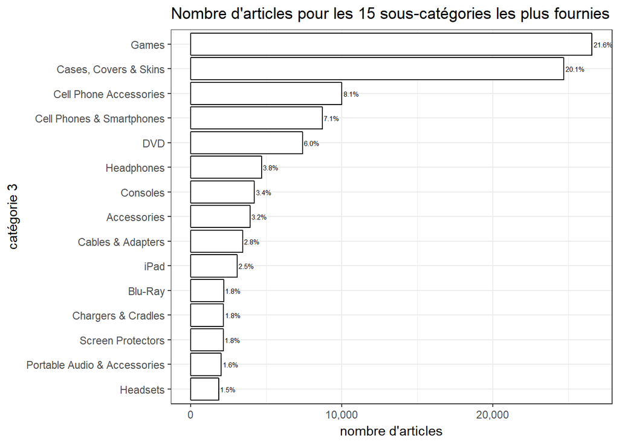

```r
# Dataframe comptant le nombre de produits par cat3
n_articles_cat3 = dataset %>%
  group_by(cat3) %>%
  summarise(effectif = n()) %>% #nombre de produits
  ungroup() %>%
  mutate(pct = 100 * effectif / sum(effectif)) %>% #pourcentage
  arrange(-effectif) #nécessaire pour ne sélectionner que les premiers

# Ordonne les levels
n_articles_cat3$cat3 = factor(n_articles_cat3$cat3,
                              levels = n_articles_cat3$cat3[order(n_articles_cat3$effectif)])

# Graphique en barre
n_head = 15
ggplot(n_articles_cat3 %>% head(n_head), aes(x = cat3, y = effectif)) +
  geom_bar(stat = 'identity', fill = "white", color = "black") +
  labs(title = paste("Nombre d'articles pour les", n_head, "sous-catégories les plus fournies"),
       x = "catégorie 3",
       y = "nombre d'articles") +
  geom_text(size = 2, hjust = -0.1, aes(y = effectif, label = sprintf("%.1f%%", pct))) +
  scale_y_continuous(labels = scales::comma) +
  coord_flip() +
  theme_bw()
```

Les résultats sont cohérents avec ceux obtenus à partir de la catégorie 2 : ici, nous voyons que les sous-catégories les plus fournies sont les jeux et les accessoires des smartphones (à eux-deux, elles représentent plus de 40% des articles en électronique).

Quelle est la structure des catégories ?

```r
structure_cat = dataset %>%
  select(cat2, cat3) %>%
  distinct() %>%
  arrange(cat2, cat3)

structure_cat
```

| cat2 | cat3 |
| --- | --- |
| Cameras & Photography | Binoculars & Telescopes |
| Cameras & Photography | Camcorders |
| Cameras & Photography | Camera & Photo Accessories |
| Cameras & Photography | Digital Cameras |
| Cameras & Photography | Film Photography |
| Cameras & Photography | Flashes & Flash Accessories |
| Cameras & Photography | Lenses & Filters |
| Cameras & Photography | Lighting & Studio |
| Cameras & Photography | Other |
| Cameras & Photography | Tripods & Supports |
| Car Audio, Video & GPS | Car Security & Convenience |
| Car Audio, Video & GPS | Car Speakers & Systems |
| Car Audio, Video & GPS | Car Stereos & Components |
| Car Audio, Video & GPS | Car Subwoofers |
| Car Audio, Video & GPS | Car Video |
| Car Audio, Video & GPS | GPS Accessories & Mounts |
| Car Audio, Video & GPS | GPS Units & Equipment |
| Car Audio, Video & GPS | Other |
| Car Audio, Video & GPS | Other Accessories |
| Cell Phones & Accessories | Batteries |
| Cell Phones & Accessories | Cables & Adapters |
| Cell Phones & Accessories | Cases, Covers & Skins |
| Cell Phones & Accessories | Cell Phone Accessories |
| Cell Phones & Accessories | Cell Phones & Smartphones |
| Cell Phones & Accessories | Chargers & Cradles |
| Cell Phones & Accessories | Headsets |
| Cell Phones & Accessories | Other |
| Cell Phones & Accessories | Screen Protectors |
| Computers & Tablets | Components & Parts |
| Computers & Tablets | Desktops & All-In-Ones |
| Computers & Tablets | Drives, Storage & Media |
| Computers & Tablets | iPad |
| Computers & Tablets | Laptops & Netbooks |
| Computers & Tablets | Networking & Connectivity |
| Computers & Tablets | Other |
| Computers & Tablets | Printers, Scanners & Supplies |
| Media | Blu-Ray |
| Media | CD |
| Media | DVD |
| Media | Other |
| Media | VHS |
| Other | Other |
| TV, Audio & Surveillance | DVD & Blu-ray Players |
| TV, Audio & Surveillance | Gadgets |
| TV, Audio & Surveillance | Headphones |
| TV, Audio & Surveillance | Home Audio |
| TV, Audio & Surveillance | Home Speakers & Subwoofers |
| TV, Audio & Surveillance | Home Surveillance |
| TV, Audio & Surveillance | Other |
| TV, Audio & Surveillance | Portable Audio & Accessories |
| TV, Audio & Surveillance | Televisions |
| Video Games & Consoles | Accessories |
| Video Games & Consoles | Consoles |
| Video Games & Consoles | Games |
| Video Games & Consoles | Other |
| Video Games & Consoles | Replacement Parts & Tools |
| Video Games & Consoles | Strategy Guides |
| Video Games & Consoles | Video Gaming Merchandise |

```r
# Nombre de familles de catégories
cat(sprintf("Il y a %.0f famille de catégories.\n", nrow(structure_cat)))
```

```
## Il y a 58 famille de catégories.
```

```r
# Nombre de modalités en cat2
cat(sprintf("Il y a %.0f modalités de cat2 uniques.\n", dataset$cat2 %>% unique() %>% length()))
```

```
## Il y a 8 modalités de cat2 uniques.
```

```r
# Nombre de modalités en cat3
cat(sprintf("Il y a %.0f modalités de cat3 uniques.\n", dataset$cat3 %>% unique() %>% length()))
```

```
## Il y a 51 modalités de cat3 uniques.
```

Nous retrouvons 58 familles de catégories (soit plus que les 51 modalités de **cat3**) car certaines proviennent de **cat2** différents comme la sous-catégorie *Other* qui est un enfant de 8 catégorie 2.

Quelles sont les marques les plus fréquentes ?

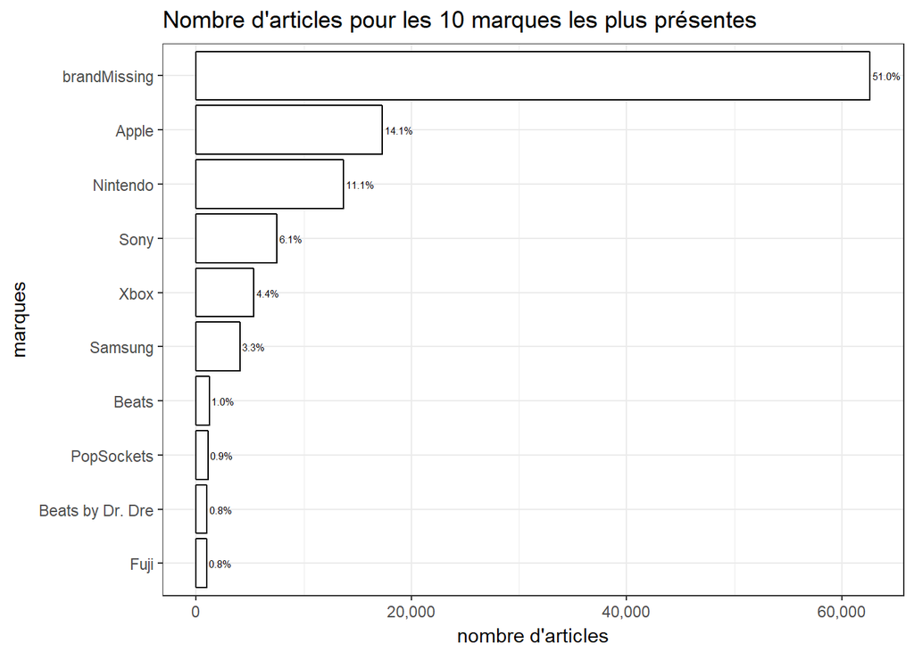

```r
# Dataframe comptant le nombre de produits par marque
n_articles_brand = dataset %>%
  group_by(brand_name) %>%
  summarise(effectif = n()) %>% #nombre de produits
  ungroup() %>%
  mutate(pct = 100 * effectif / sum(effectif)) %>% #pourcentage
  arrange(-effectif) #nécessaire pour ne sélectionner que les premiers

# Ordonne les levels
n_articles_brand$brand_name = factor(n_articles_brand$brand_name,
                              levels = n_articles_brand$brand_name[order(n_articles_brand$effectif)])

# Graphique en barre
n_head = 10
ggplot(n_articles_brand %>% head(n_head), aes(x = brand_name, y = effectif)) +
  geom_bar(stat = 'identity', fill = "white", color = "black") +
  labs(title = paste("Nombre d'articles pour les", n_head, "marques les plus présentes"),
       x = "marques",
       y = "nombre d'articles") +
  geom_text(size = 2, hjust = -0.1, aes(y = effectif, label = sprintf("%.1f%%", pct))) +
  scale_y_continuous(labels = scales::comma) +
  coord_flip() +
  theme_bw()
```

```r
# Nombre de marques différentes
cat(sprintf("Il y a %.0f marques différentes.\n", nrow(n_articles_brand)))
```

```
## Il y a 308 marques différentes.
```

Un article sur deux n’a pas de marque ! Puis viennent les marques les plus présents dans les jeux vidéos ou les smartphones (logique!) comme Apple, Nintendo, Sony, Xbox et Samsung.

Il convient de rassembler sous un même label les marques les moins présentes

```r
# Les marques les plus présentes (plus de 2.5% des articles en volume)
marques_les_plus_presentes = n_articles_brand$brand_name[n_articles_brand$pct > 2.5]

# Remplacement des noms des autres marques
dataset$brand_name = ifelse(dataset$brand_name %in% marques_les_plus_presentes,
                            dataset$brand_name,
                            "otherBrand")
```

Vérifions que l’agrégation s’est bien faite :

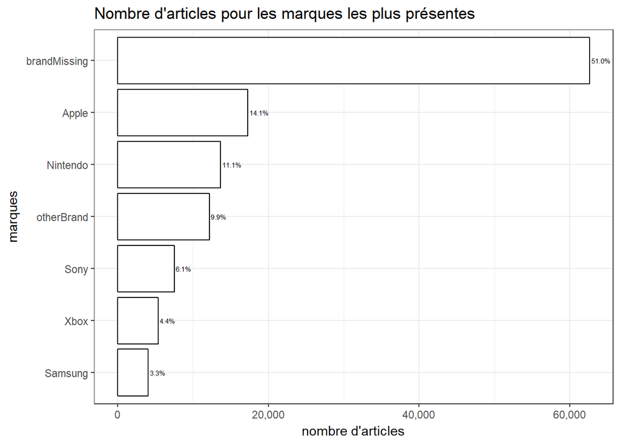

```r
# Dataframe comptant le nombre de produits par marque après agrégation des petites marques
n_articles_brand_afterAgreg = dataset %>%
  group_by(brand_name) %>%
  summarise(effectif = n()) %>% #nombre de produits
  ungroup() %>%
  mutate(pct = 100 * effectif / sum(effectif)) %>% #pourcentage
  arrange(-effectif) #nécessaire pour ne sélectionner que les premiers

# Ordonne les levels
n_articles_brand_afterAgreg$brand_name = factor(n_articles_brand_afterAgreg$brand_name,
                                                levels = n_articles_brand_afterAgreg$brand_name[order(n_articles_brand_afterAgreg$effectif)])

# Graphique en barre
ggplot(n_articles_brand_afterAgreg, aes(x = brand_name, y = effectif)) +
  geom_bar(stat = 'identity', fill = "white", color = "black") +
  labs(title = paste("Nombre d'articles pour les marques les plus présentes"),
       x = "marques",
       y = "nombre d'articles") +
  geom_text(size = 2, hjust = -0.1, aes(y = effectif, label = sprintf("%.1f%%", pct))) +
  scale_y_continuous(labels = scales::comma) +
  coord_flip() +
  theme_bw()
```

```r
# Nombre de marques différentes
cat(sprintf("Il y a %.0f marques différentes.\n", nrow(n_articles_brand_afterAgreg)))
```

```
## Il y a 7 marques différentes.
```

Quelle est la répartition des prix ?

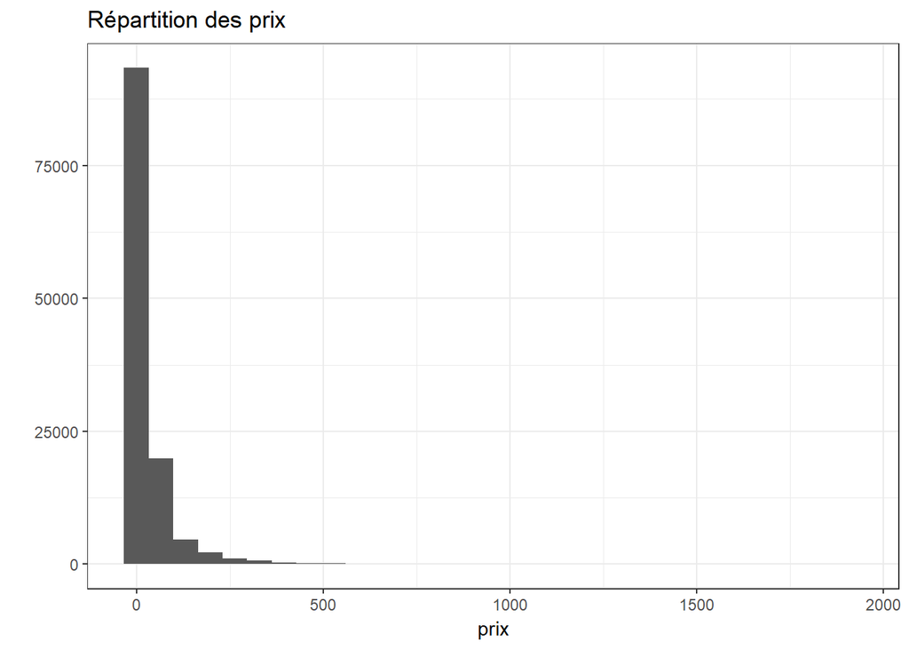

```r
# Graphique
ggplot(dataset, aes(x = price)) +
  geom_histogram() +
  labs(title = "Répartition des prix",
       x = "prix",
       y = "") +
  theme_bw()
```

```r
# Etendue
summary(dataset$price)
```

```
##    Min. 1st Qu.  Median    Mean 3rd Qu.    Max.
##    0.00    9.00   15.00   35.17   31.00 1909.00
```

Nous constatons la présence d’une longue queue. En accord avec la métrique RMSLE et cette remarque, nous considérons le log du prix.  
De plus, l’existence de produits vendus à un prix nul étant problématique, nous les retirons de l’étude.

```r
# Produits vendus à 0$
dataset %>% filter(price <= 0) %>% head(5)
```

| train_id | name | item_condition_id | cat2 | cat3 | brand_name | price | shipping | item_description | is_brand_missing |
| --- | --- | --- | --- | --- | --- | --- | --- | --- | --- |
| 6175 | Multi Listing Bundled Package, Thanks | 2 | Media | DVD | brandMissing | 0 | 1 | 1)Large Collection of Full Length Strawberry Shortcake DVD Movies, Set of 7 All gently used, no scratches Titles Include: ° Big Lights, Big Dreams ° The Glimmerberry Ball Movie ° Jammin With Cherry Ja… | TRUE |
| 7622 | Hands free earpiece | 1 | Cell Phones & Accessories | Headsets | brandMissing | 0 | 0 | Wireless Bluetooth hands free used with Samsung phones | TRUE |
| 45765 | PS4, Call Of duty Infinite Warfare | 3 | Video Games & Consoles | Video Gaming Merchandise | brandMissing | 0 | 0 | Slightly Used | TRUE |
| 52103 | Wii Motion Sensor | 3 | Video Games & Consoles | Accessories | Nintendo | 0 | 1 | Used. In working condition. | FALSE |
| 58900 | Apple Silicone Case iPhone 6s Plus | 4 | Cell Phones & Accessories | Cell Phone Accessories | Apple | 0 | 1 | Used in okay condition. All marks are pictured. It’s apple brand. | FALSE |

```r
cat(sprintf("Il y a %.0f articles dont le prix est inférieur à 0.\n", sum(dataset$price <= 0)))
```

```
## Il y a 58 articles dont le prix est inférieur à 0.
```

```r
dataset = dataset %>% filter(price > 0)
```

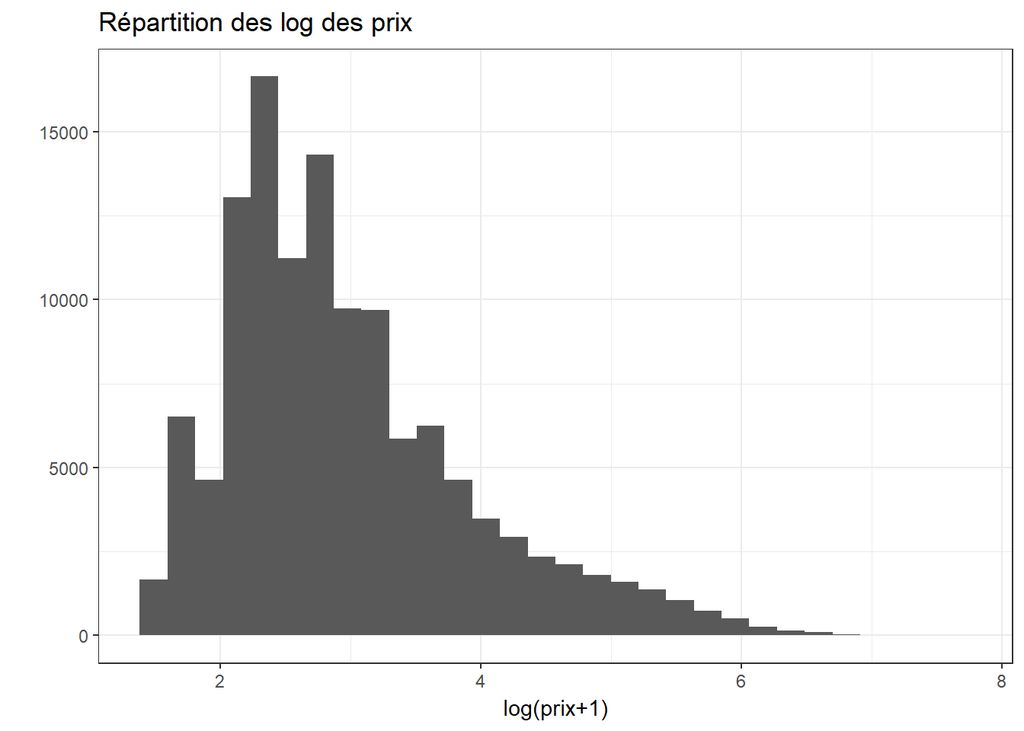

```r
# Création du log du prix
dataset = dataset %>%
  mutate(log_price = log(price + 1))

# Histogramme du log des prix
ggplot(dataset, aes(x = log_price)) +
  geom_histogram() +
  labs(title = "Répartition des log des prix",
       x = "log(prix+1)",
       y = "") +
  theme_bw()
```

```r
# Etendue
summary(dataset$log_price)
```

```
##    Min. 1st Qu.  Median    Mean 3rd Qu.    Max.
##   1.386   2.303   2.773   2.988   3.466   7.555
```

Quelle est la répartition des frais de port ?

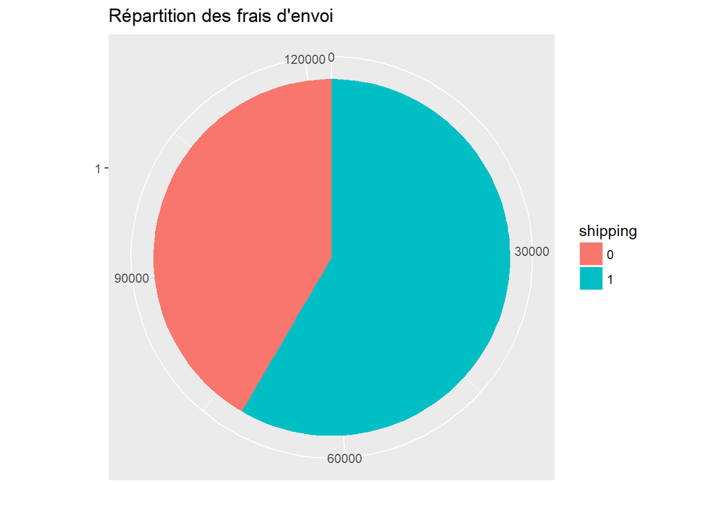

```r
# Dataframe comptant le nombre de produits par payeur des frais d'expédition
n_articles_shipping = dataset %>%
  group_by(shipping) %>%
  summarise(effectif = n()) %>% #nombre de produits
  ungroup()

# Mise en facteur de shipping
n_articles_shipping$shipping = n_articles_shipping$shipping %>% as.factor()

# Camembert
ggplot(n_articles_shipping, aes(x = factor(1) , y = effectif, fill = shipping)) +
  geom_bar(stat = 'identity', width = 1) +
  labs(title = "Répartition des frais d'envoi",
       x = "",
       y = "") +
  coord_polar(theta = "y")
```

# 5 Sauvegarde

```r
# Sauvegarde des données filtrées et corrigées
fwrite(dataset, "./data/intermediate/dataset_electronics.csv",
       row.names = FALSE, quote = TRUE, sep = ";")
```